# Infection Intensity Data Analysis

Lindsay E. Martin

2023-05-02

```r
# clear existing workspace
rm(list = ls(all = TRUE))
graphics.off()
shell("cls")

#set wd to your project folder
#setwd("C:/Users/linzm/'OneDrive - Vanderbilt'/Hillyer_Lab/Infection_Intensity") #modfiy this as need be
getwd() #check working directory
```

```
## [1] "C:/Users/linzm/OneDrive - Vanderbilt/Hillyer_Lab/Infection_Intensity"
```

```r
#load libraries needed:
library(readxl)
library(writexl)
library(ggplot2)
library(dplyr)
library(ggpubr)
library(tidyverse)
library(ggpubr)
library(rstatix)
library(car)
library(rcompanion)
library(boot)
library(ggpubr)
library(lattice)
library(MASS)
require(pscl)
library(lmtest)
library(sandwich)
require(foreign)
require(fitdistrplus)
require(RColorBrewer)
library(ggeffects)
library(splines)
library(sjPlot)
library(ggplot2)
library(emmeans)
########################
#import the data:
II_Data <- read_xlsx("Infection_Intensity_Data_JS_May2022.xlsx",
                     sheet = "R")
                     #col_types = c()) #import all PO Data

#format factors:
#Temperature and Age are continuous variables
II_Data$Block <- as.factor(II_Data$Block)
str(II_Data)
```

```
## tibble [696 × 7] (S3: tbl_df/tbl/data.frame)
##  $ Trial          : num [1:696] 1 1 1 1 1 1 1 1 1 2 ...
##  $ ID             : num [1:696] 1 2 3 4 5 6 7 8 9 1 ...
##  $ Temperature    : num [1:696] 27 27 27 27 27 27 27 27 27 27 ...
##  $ Age            : num [1:696] 1 1 1 1 1 1 1 1 1 1 ...
##  $ CFUs           : num [1:696] 26000 7500 14500 28500 157500 ...
##  $ Block          : Factor w/ 20 levels "1","2","3","4",..: 1 1 1 1 1 1 1 1 1 2 ...
##  $ Infectious_Dose: num [1:696] 25254 25254 25254 25254 25254 ...
```

```r
##
#center the temp and age variables:
#centering helps when doing regression so that the intercepts make sense in interpreting the data

#save original data first as original
II_Data$Temperature_uncentered <- II_Data$Temperature
II_Data$Age_uncentered <- II_Data$Age

#now center (take average and then subtract individ value):
II_Data$Temperature <- scale(II_Data$Temperature, center=TRUE,scale=FALSE)
II_Data$Age <- scale(II_Data$Age, center=TRUE,scale=FALSE)

str(II_Data)
```

```
## tibble [696 × 9] (S3: tbl_df/tbl/data.frame)
##  $ Trial                 : num [1:696] 1 1 1 1 1 1 1 1 1 2 ...
##  $ ID                    : num [1:696] 1 2 3 4 5 6 7 8 9 1 ...
##  $ Temperature           : num [1:696, 1] -2.76 -2.76 -2.76 -2.76 -2.76 ...
##   ..- attr(*, "scaled:center")= num 29.8
##  $ Age                   : num [1:696, 1] -6.3 -6.3 -6.3 -6.3 -6.3 ...
##   ..- attr(*, "scaled:center")= num 7.3
##  $ CFUs                  : num [1:696] 26000 7500 14500 28500 157500 ...
##  $ Block                 : Factor w/ 20 levels "1","2","3","4",..: 1 1 1 1 1 1 1 1 1 2 ...
##  $ Infectious_Dose       : num [1:696] 25254 25254 25254 25254 25254 ...
##  $ Temperature_uncentered: num [1:696] 27 27 27 27 27 27 27 27 27 27 ...
##  $ Age_uncentered        : num [1:696] 1 1 1 1 1 1 1 1 1 1 ...
```

```r
#change character type to just numeric instead of scaled variable
II_Data$Temperature <- as.numeric(II_Data$Temperature)
II_Data$Age <- as.numeric(II_Data$Age)

str(II_Data)
```

```
## tibble [696 × 9] (S3: tbl_df/tbl/data.frame)
##  $ Trial                 : num [1:696] 1 1 1 1 1 1 1 1 1 2 ...
##  $ ID                    : num [1:696] 1 2 3 4 5 6 7 8 9 1 ...
##  $ Temperature           : num [1:696] -2.76 -2.76 -2.76 -2.76 -2.76 ...
##  $ Age                   : num [1:696] -6.3 -6.3 -6.3 -6.3 -6.3 ...
##  $ CFUs                  : num [1:696] 26000 7500 14500 28500 157500 ...
##  $ Block                 : Factor w/ 20 levels "1","2","3","4",..: 1 1 1 1 1 1 1 1 1 2 ...
##  $ Infectious_Dose       : num [1:696] 25254 25254 25254 25254 25254 ...
##  $ Temperature_uncentered: num [1:696] 27 27 27 27 27 27 27 27 27 27 ...
##  $ Age_uncentered        : num [1:696] 1 1 1 1 1 1 1 1 1 1 ...
```

```r
#round to 2 digits each:
II_Data$Temperature <- round(II_Data$Temperature, 2)
str(II_Data$Temperature)
```

```
##  num [1:696] -2.76 -2.76 -2.76 -2.76 -2.76 -2.76 -2.76 -2.76 -2.76 -2.76 ...
```

```r
II_Data$Age <-round(II_Data$Age, 1)
str(II_Data$Age)
```

```
##  num [1:696] -6.3 -6.3 -6.3 -6.3 -6.3 -6.3 -6.3 -6.3 -6.3 -6.3 ...
```

```r
###
#how centering works
unique(II_Data$Temperature)
```

```
## [1] -2.76  0.24  2.24
```

```r
mean(II_Data$Temperature_uncentered) #29.76293 is mean temp (29.7C)
```

```
## [1] 29.76293
```

```r
mean(II_Data$Temperature) #mean now approximates zero
```

```
## [1] 0.002931034
```

```r
unique(II_Data$Age)
```

```
## [1] -6.3 -2.3  2.7  7.7
```

```r
mean(II_Data$Age_uncentered) #7.298851 is mean age (7 days)
```

```
## [1] 7.298851
```

```r
mean(II_Data$Age) #approximates zero
```

```
## [1] -0.001149425
```

```r
####

#create labels for axes
templabs <- c("27˚C","30˚C","32˚C")
names(templabs)<- c("-2.76","0.24","2.24") #assign centered values

agelabs <- c("1 day","5 days", "10 days", "15 days")
names(agelabs)<-c("-6.3","-2.3","2.7","7.7") #assign centered values

#check:
templabs
```

```
##  -2.76   0.24   2.24
## "27˚C" "30˚C" "32˚C"
```

```r
agelabs
```

```
##      -6.3      -2.3       2.7       7.7
##   "1 day"  "5 days" "10 days" "15 days"
```

## Exploring the Data

First, we will plot the data to see what it looks like for each temperature-age combination.

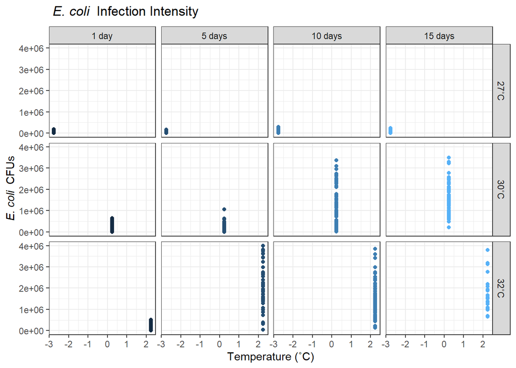

```r
II_Data %>%
  count(Temperature,CFUs,Age)%>%
  ggplot(aes(x=Temperature,y=CFUs,color=Age))+
  scale_shape_identity(guide="legend")+
  geom_point()+
  facet_grid(Temperature~Age, labeller = labeller(Age=agelabs, Temperature=templabs))+
  labs(title=~italic("E. coli")~" Infection Intensity",
       x="Temperature (˚C)",parse=TRUE)+
  ylab(expression(~italic("E. coli")~" CFUs"))+theme_bw()+
  theme(legend.position = "none")
```

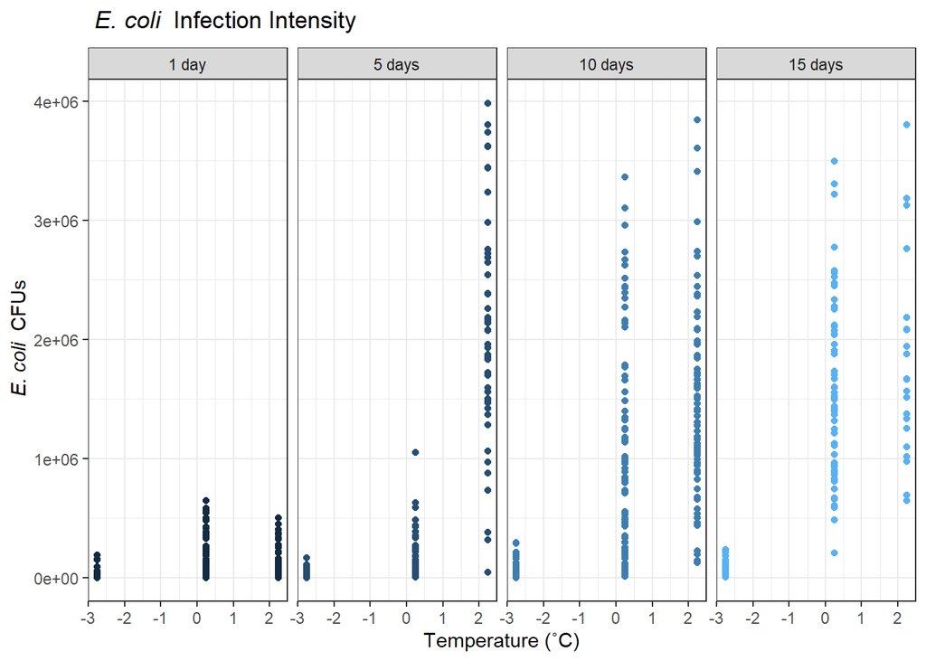

```r
II_Data %>%
  count(Temperature,CFUs,Age)%>%
  ggplot(aes(x=Temperature,y=CFUs,color=Age))+
  scale_shape_identity(guide="legend")+
  geom_point()+
  facet_grid(~Age, labeller = labeller(Age=agelabs, Temperature=templabs))+
  labs(title=~italic("E. coli")~" Infection Intensity",
       x="Temperature (˚C)",parse=TRUE)+
  ylab(expression(~italic("E. coli")~" CFUs"))+theme_bw()+
  theme(legend.position = "none")
```

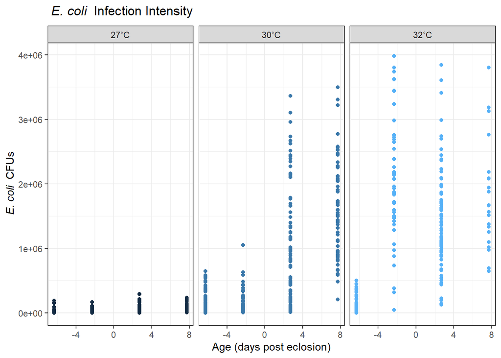

```r
II_Data %>%
  count(Temperature,CFUs,Age)%>%
  ggplot(aes(x=Age,y=CFUs,color=Temperature))+
  scale_shape_identity(guide="legend")+
  geom_point()+
  facet_grid(~Temperature, labeller = labeller(Age=agelabs, Temperature=templabs))+
  labs(title=~italic("E. coli")~" Infection Intensity",
       x="Age (days post eclosion)",parse=TRUE)+
  ylab(expression(~italic("E. coli")~" CFUs"))+theme_bw()+
  theme(legend.position = "none")
```

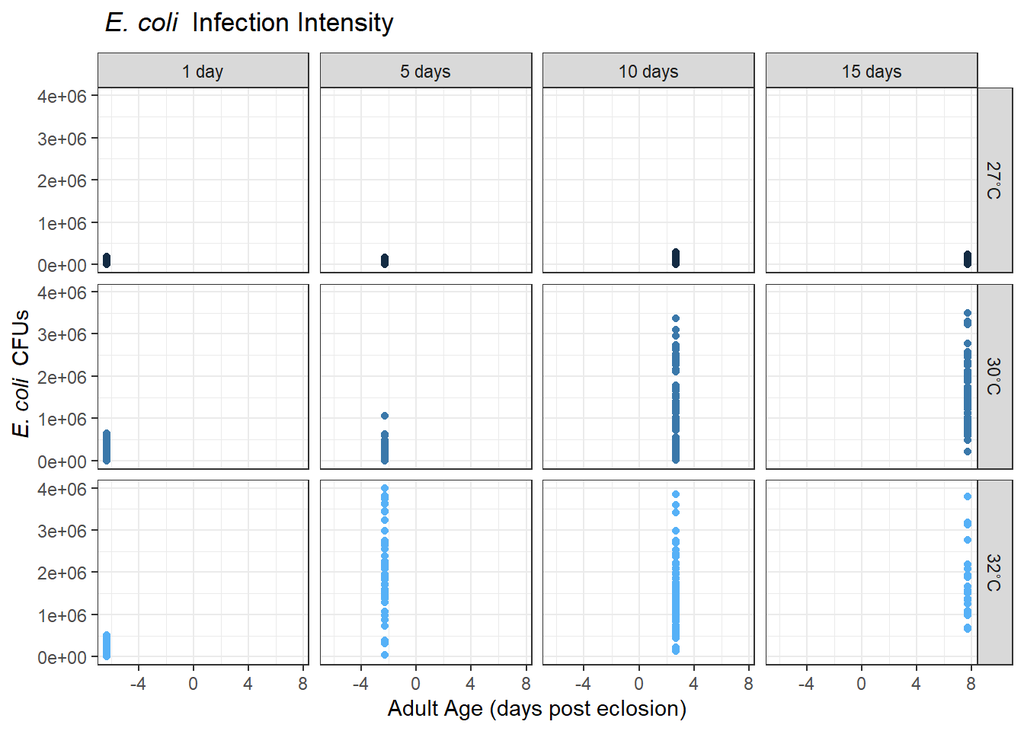

```r
#Graph 1b: raw data, age vs. CFUs
II_Data %>%
  count(Temperature,CFUs,Age)%>%
  ggplot(aes(x=Age,y=CFUs, color=Temperature))+
  scale_shape_identity(guide="legend")+
  geom_point()+
  facet_grid(Temperature~Age, labeller = labeller(Age=agelabs, Temperature=templabs))+
  labs(title=~italic("E. coli")~" Infection Intensity",
       x="Adult Age (days post eclosion)",parse=TRUE)+
  ylab(expression(~italic("E. coli")~" CFUs"))+theme_bw()+
  theme(legend.position = "none")
```

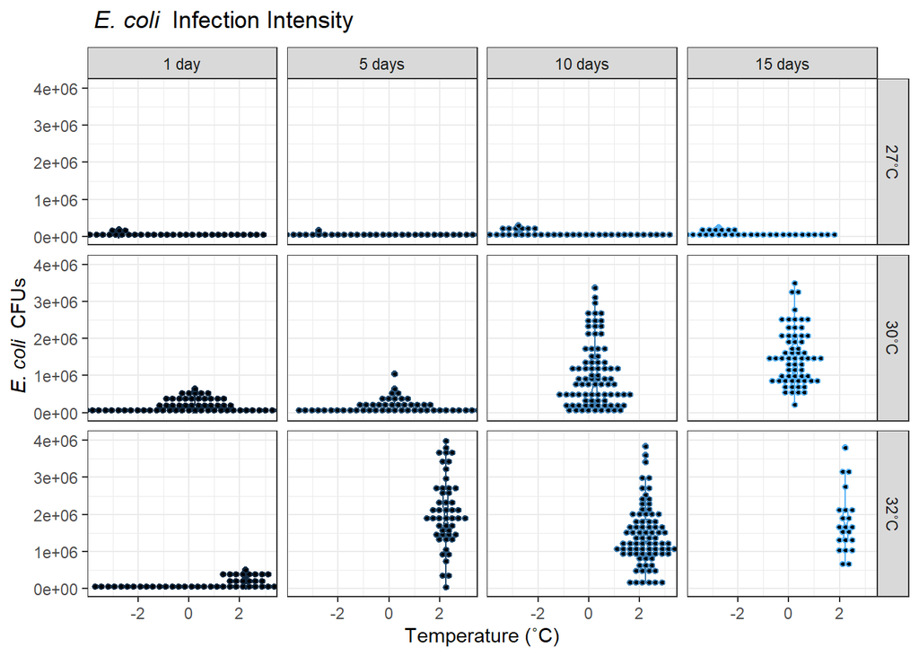

```r
#Graph 2a: box plot of raw data, temp vs. CFUs
II_Data %>%
  ggplot(aes(x=Temperature,y=CFUs,color=Age,group=Temperature))+
  facet_grid(Temperature~Age, labeller = labeller(Age=agelabs, Temperature=templabs))+
  labs(title=~italic("E. coli")~" Infection Intensity",
       x="Temperature (˚C)")+
  ylab(expression(~italic("E. coli")~" CFUs"))+
  #stat_summary(fun=mean,geom="point",shape=23,size=4)+
  geom_boxplot(notch = TRUE)+theme_bw()+
  geom_dotplot(binaxis='y', stackdir='center', dotsize=1.3)+
  theme(legend.position = "none")
```

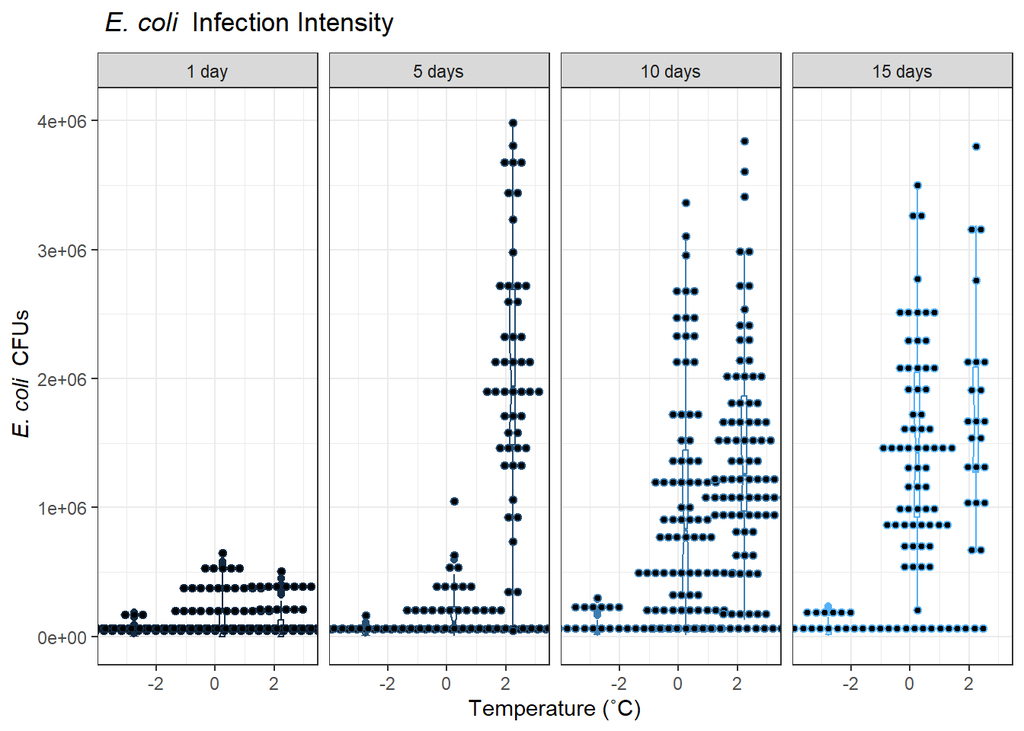

```r
II_Data %>%
  ggplot(aes(x=Temperature,y=CFUs,color=Age,group=Temperature))+
  facet_grid(~Age, labeller = labeller(Age=agelabs, Temperature=templabs))+
  labs(title=~italic("E. coli")~" Infection Intensity",
       x="Temperature (˚C)")+
  ylab(expression(~italic("E. coli")~" CFUs"))+
  geom_boxplot(notch = TRUE)+theme_bw()+
  geom_dotplot(binaxis='y', stackdir='center', dotsize=0.5)+
  theme(legend.position = "none")
```

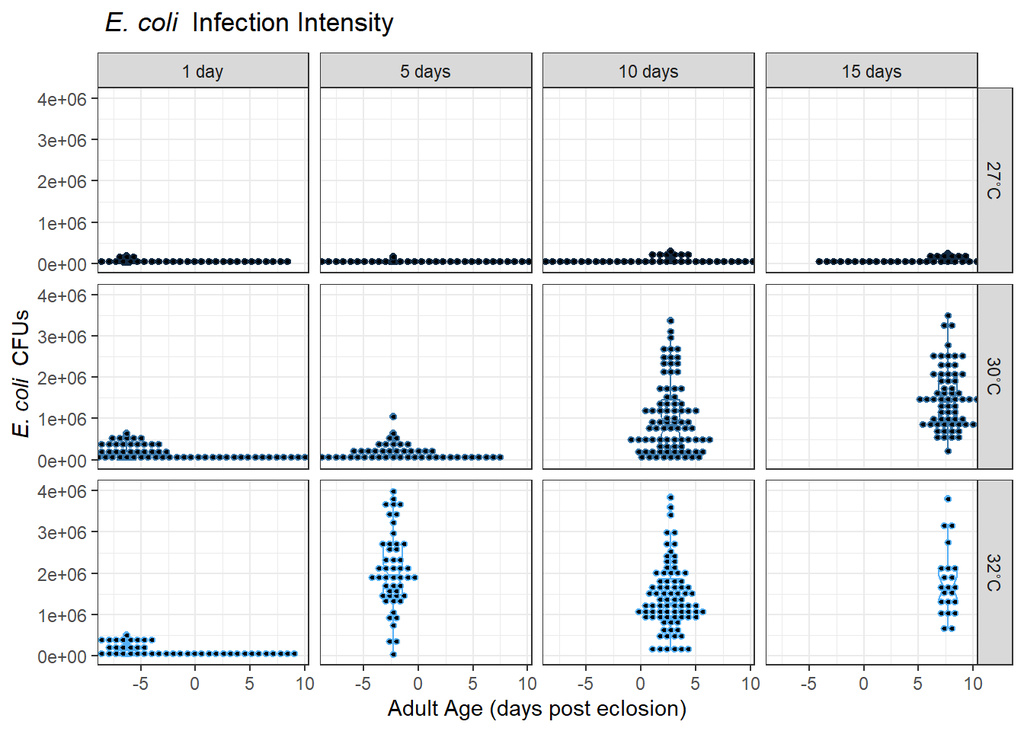

```r
#Graph 2b: box plot of raw data, temp vs. CFUs
II_Data %>%
  ggplot(aes(x=Age,y=CFUs,color=Temperature,group=Age))+
  facet_grid(Temperature~Age, labeller = labeller(Age=agelabs, Temperature=templabs))+
  labs(title=~italic("E. coli")~" Infection Intensity",
       x="Adult Age (days post eclosion)")+
  ylab(expression(~italic("E. coli")~" CFUs"))+
  #stat_summary(fun=mean,geom="point",shape=23,size=4)+
  geom_boxplot(notch = TRUE)+theme_bw()+
  geom_dotplot(binaxis='y', stackdir='center', dotsize=1.3)+
  theme(legend.position = "none")
```

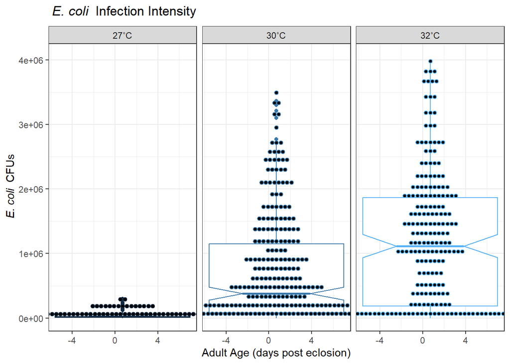

```r
II_Data %>%
  ggplot(aes(x=Age,y=CFUs,color=Temperature,group = Temperature))+
  facet_grid(~Temperature, labeller = labeller(Age=agelabs, Temperature=templabs))+
  labs(title=~italic("E. coli")~" Infection Intensity",
       x="Adult Age (days post eclosion)")+
  ylab(expression(~italic("E. coli")~" CFUs"))+
  geom_boxplot(notch = TRUE)+theme_bw()+
  geom_dotplot(binaxis='y', stackdir='center', dotsize=0.5)+
  theme(legend.position = "none")
```

## Data Summary Figures

Then, we can calculate the mean, median, SE, SD for further exploration.

```r
#calculate the mean, median, SE, sd, etc.:
II_Summary <- II_Data %>%
  group_by(Temperature,Age) %>%
  summarise(mean_CFUs = mean(CFUs),
            median_CFUs = median(CFUs),
            sd_CFUs = sd(CFUs),
            n_CFUs = n(),
            SE_CFUs = sd(CFUs)/sqrt(n()))
II_Summary
```

```
## # A tibble: 12 × 7
## # Groups:   Temperature [3]
##    Temperature   Age mean_CFUs median_CFUs sd_CFUs n_CFUs SE_CFUs
##          <dbl> <dbl>     <dbl>       <dbl>   <dbl>  <int>   <dbl>
##  1       -2.76  -6.3    24184.        9000  40608.     49   5801.
##  2       -2.76  -2.3    28317.       17250  31429.     52   4358.
##  3       -2.76   2.7    58540.       32000  70364.     55   9488.
##  4       -2.76   7.7    60395.       43000  57644.     43   8791.
##  5        0.24  -6.3   132343.       42000 174500.     83  19154.
##  6        0.24  -2.3   177981.      112500 194841.     52  27020.
##  7        0.24   2.7  1032000       832000 863025.     83  94729.
##  8        0.24   7.7  1521143.     1432000 741178.     63  93380.
##  9        2.24  -6.3   101000        28500 141758.     63  17860.
## 10        2.24  -2.3  2066082.     1932000 940495.     49 134356.
## 11        2.24   2.7  1430341.     1254000 792195.     82  87483.
## 12        2.24   7.7  1796727.     1664000 820936.     22 175024.
```

We can graph the arithmetic means with standard errors:

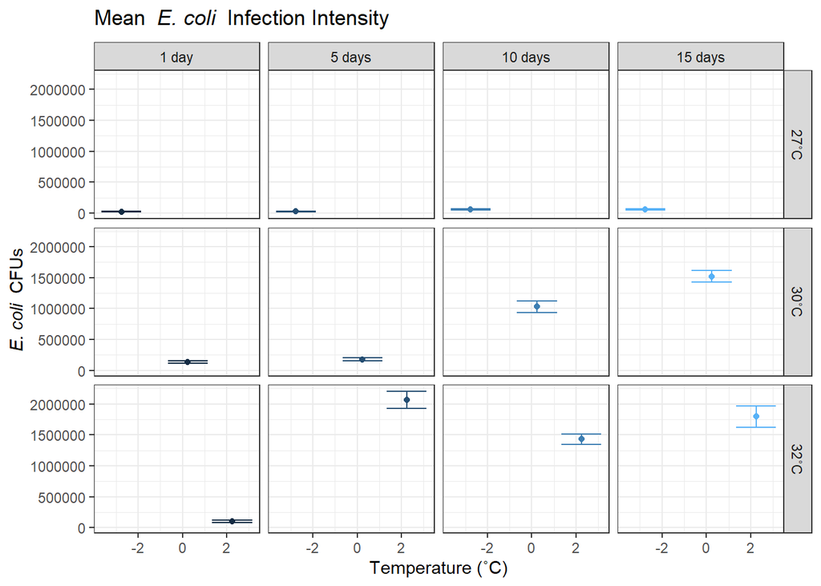

```r
#arithmetic means graphed:
II_Summary %>%
  count(Temperature,mean_CFUs,Age,SE_CFUs)%>%
  ggplot(aes(x=Temperature,y=mean_CFUs,color=Age,
             ymin=mean_CFUs-SE_CFUs, ymax=mean_CFUs+SE_CFUs))+
  geom_point()+
  facet_grid(Temperature~Age, labeller = labeller(Age=agelabs, Temperature=templabs))+
  labs(title="Mean "~italic("E. coli")~" Infection Intensity",
       x="Temperature (˚C)")+
  ylab(expression(~italic("E. coli")~" CFUs"))+
  geom_errorbar()+ theme_bw()+
  scale_shape(guide="none") + theme(legend.position = "none")
```

```r
head(II_Summary)
```

```
## # A tibble: 6 × 7
## # Groups:   Temperature [2]
##   Temperature   Age mean_CFUs median_CFUs sd_CFUs n_CFUs SE_CFUs
##         <dbl> <dbl>     <dbl>       <dbl>   <dbl>  <int>   <dbl>
## 1       -2.76  -6.3    24184.        9000  40608.     49   5801.
## 2       -2.76  -2.3    28317.       17250  31429.     52   4358.
## 3       -2.76   2.7    58540.       32000  70364.     55   9488.
## 4       -2.76   7.7    60395.       43000  57644.     43   8791.
## 5        0.24  -6.3   132343.       42000 174500.     83  19154.
## 6        0.24  -2.3   177981.      112500 194841.     52  27020.
```

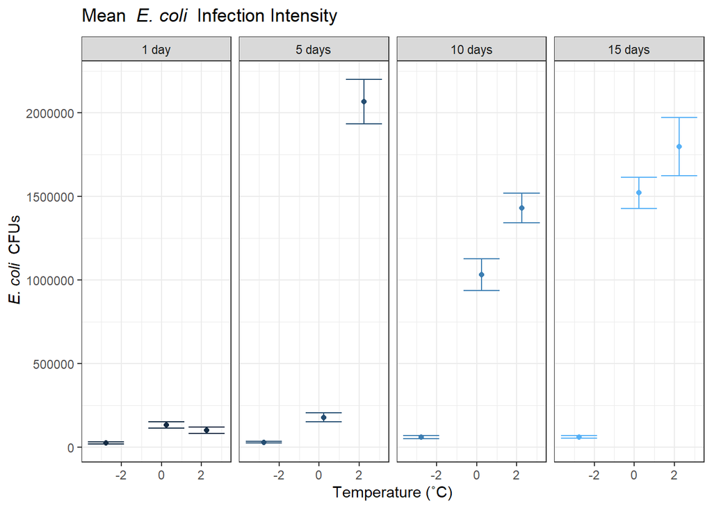

```r
II_Summary %>%
  count(Temperature,mean_CFUs,Age,SE_CFUs)%>%
  ggplot(aes(x=Temperature,y=mean_CFUs,color=Age,
             ymin=mean_CFUs-SE_CFUs, ymax=mean_CFUs+SE_CFUs))+
  geom_point()+
  facet_grid(~Age, labeller = labeller(Age=agelabs, Temperature=templabs))+
  labs(title="Mean "~italic("E. coli")~" Infection Intensity",
       x="Temperature (˚C)")+
  ylab(expression(~italic("E. coli")~" CFUs"))+
  geom_errorbar()+ theme_bw()+
  scale_shape(guide="none") + theme(legend.position = "none")
```

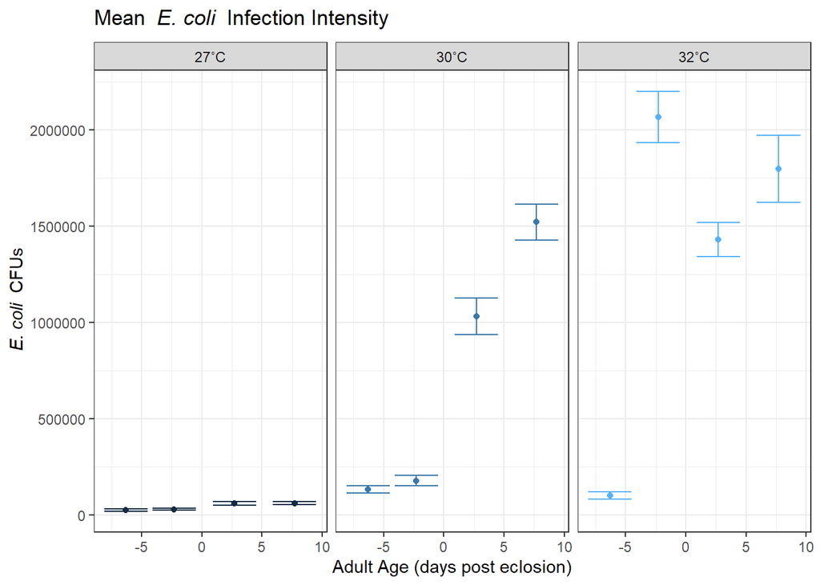

```r
II_Summary %>%
  count(Temperature,mean_CFUs,Age,SE_CFUs)%>%
  ggplot(aes(x=Age,y=mean_CFUs,color=Temperature,
             ymin=mean_CFUs-SE_CFUs, ymax=mean_CFUs+SE_CFUs))+
  geom_point()+
  facet_grid(~Temperature, labeller = labeller(Age=agelabs, Temperature=templabs))+
  labs(title="Mean "~italic("E. coli")~" Infection Intensity",
       x="Adult Age (days post eclosion)")+
  ylab(expression(~italic("E. coli")~" CFUs"))+
  geom_errorbar()+ theme_bw()+
  scale_shape(guide="none") + theme(legend.position = "none")
```

## Preliminary Data Analysis and Model Fitting

What is the distribution of the data? Are there any correlations? What can we determine from assessing the variance, etc.?

We are not log-transforming the data because of the zero values at 27C, but we don’t want to exclude this data either.

Common models for count data include the negative binomial regression, zero-inflated regression, and Poisson regression.

Helpful resources:

Delignette-Muller, M. L., & Dutang, C. (2015). fitdistrplus: An R Package for Fitting Distributions. Journal of Statistical Software, 64(4), 1–34. Alexander, N., 2012. Review: analysis of parasite and other skewed counts. Tropical Medicine & International Health 17, 684–693.. doi:10.1111/j.1365-3156.2012.02987.x https://doi.org/10.18637/jss.v064.i04 https://data.princeton.edu/wws509/r/overdispersion https://fukamilab.github.io/BIO202/04-C-zero-data.html https://stats.oarc.ucla.edu/r/dae/negative-binomial-regression/ https://www.jstatsoft.org/article/view/v027i08

```r
#check for correlations
require(GGally)
```

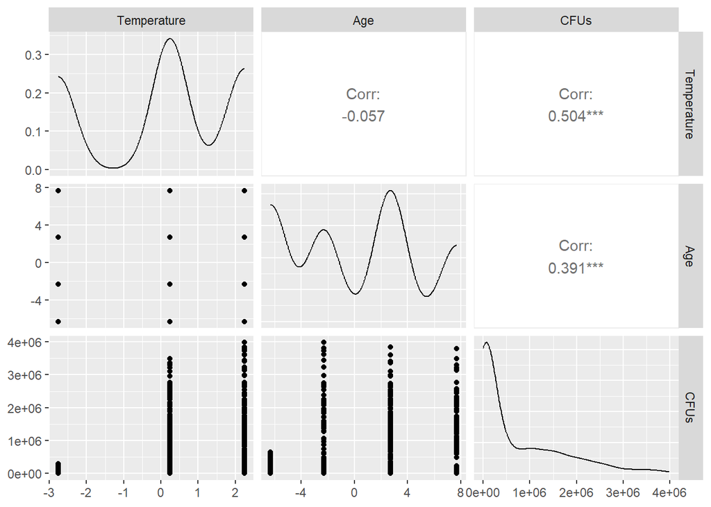

```r
ggpairs(II_Data[,c('Temperature','Age','CFUs')])
```

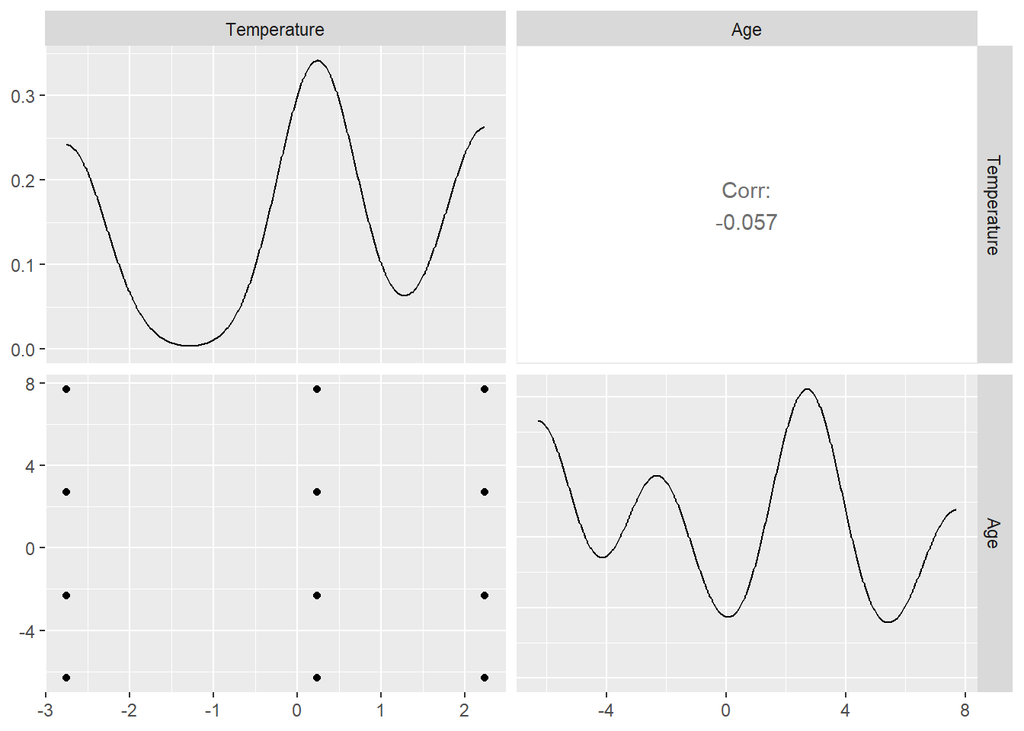

```r
ggpairs(II_Data[,c('Temperature','Age')])
```

Plot histograms of the data and subsetted data.

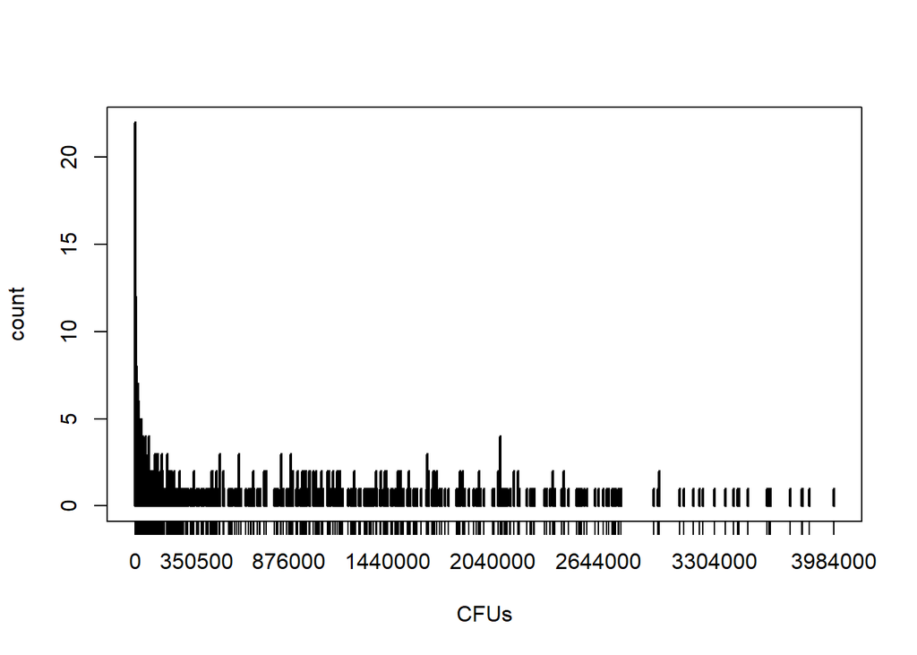

```r
#plot a histogram of the data:
plot(table(II_Data$CFUs),xlab = "CFUs",ylab="count",data=II_Data)
```

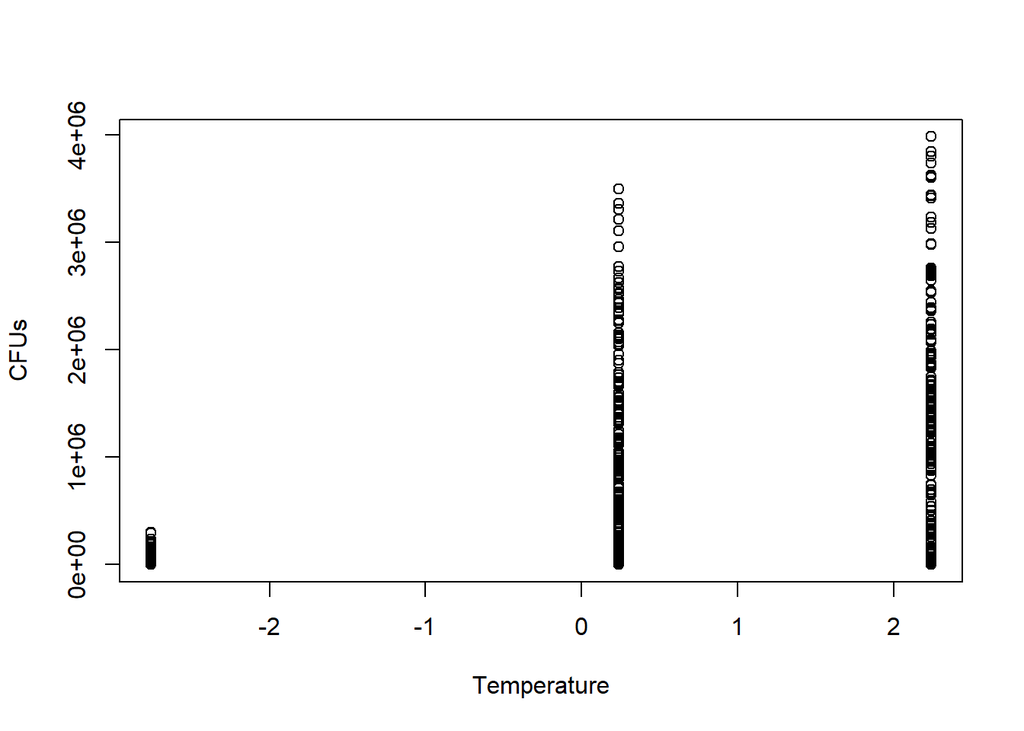

```r
plot(CFUs ~ Temperature, data = II_Data)
```

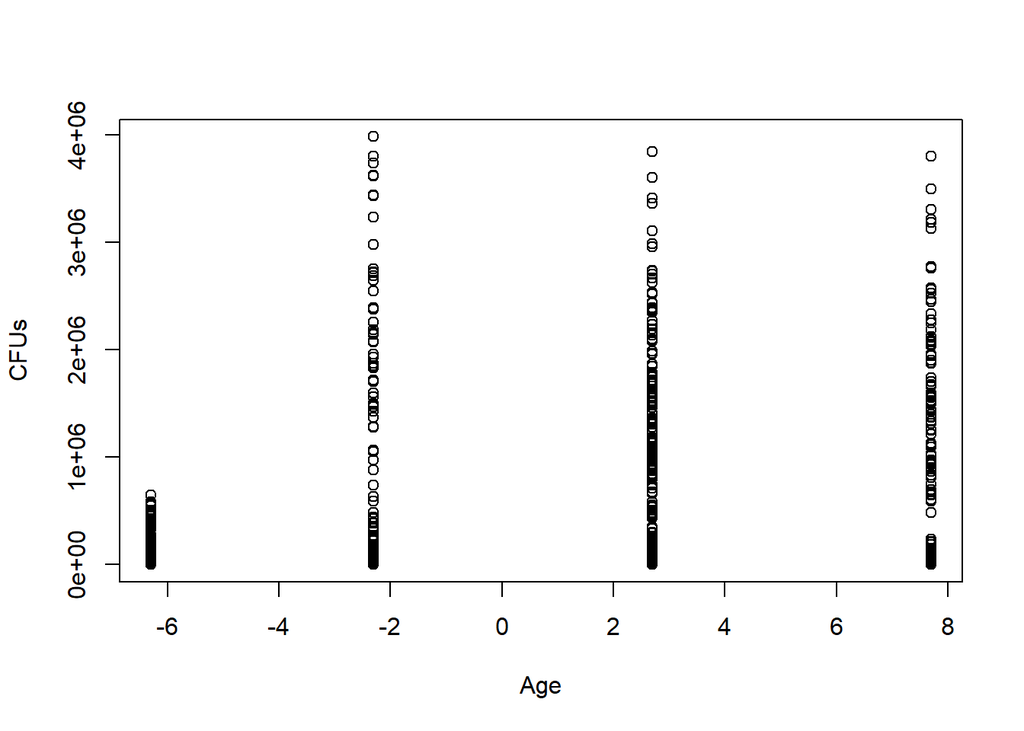

```r
plot(CFUs ~ Age, data = II_Data)
```

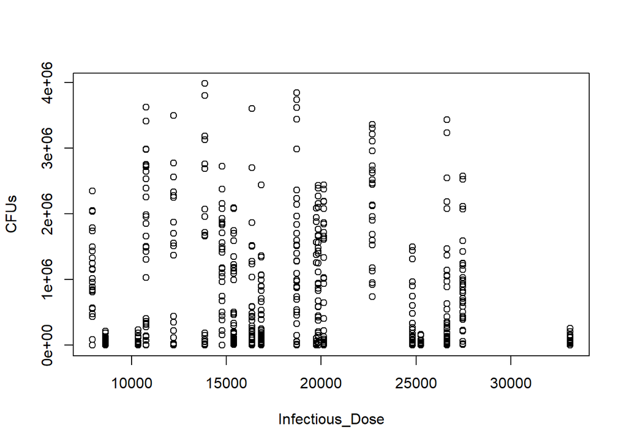

```r
plot(CFUs ~ Infectious_Dose, data = II_Data)
```

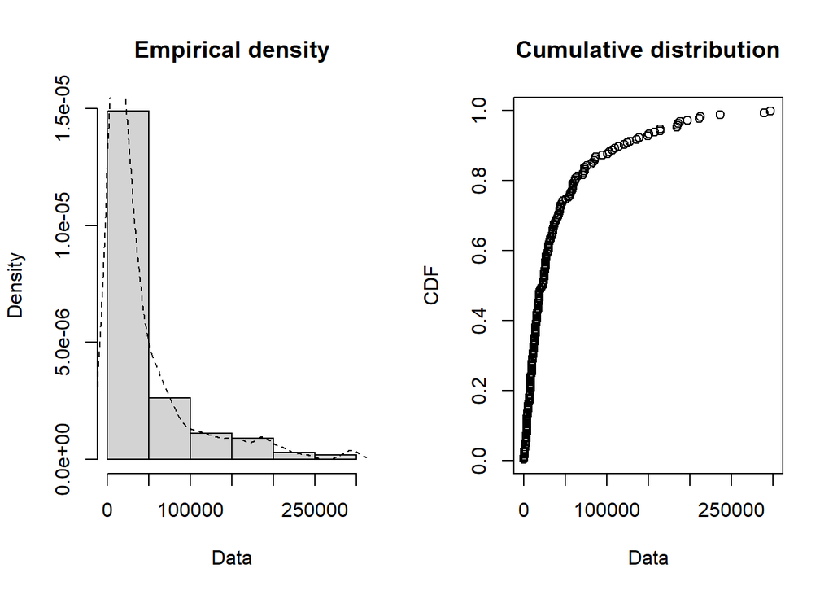

```r
#names(templabs)<- c("-2.76","0.24","2.24") #assign centered values
#names(agelabs)<-c("-6.3","-2.3","2.7","7.7")
#subset data by temperature
II_Data_27C <- subset(II_Data,Temperature==-2.76)
II_Data_30C <- subset(II_Data,Temperature==0.24)
II_Data_32C <- subset(II_Data,Temperature==2.24)

#plot the empirical distribution and density (CDF)
plotdist(II_Data_27C$CFUs, histo=TRUE,demp=TRUE)
```

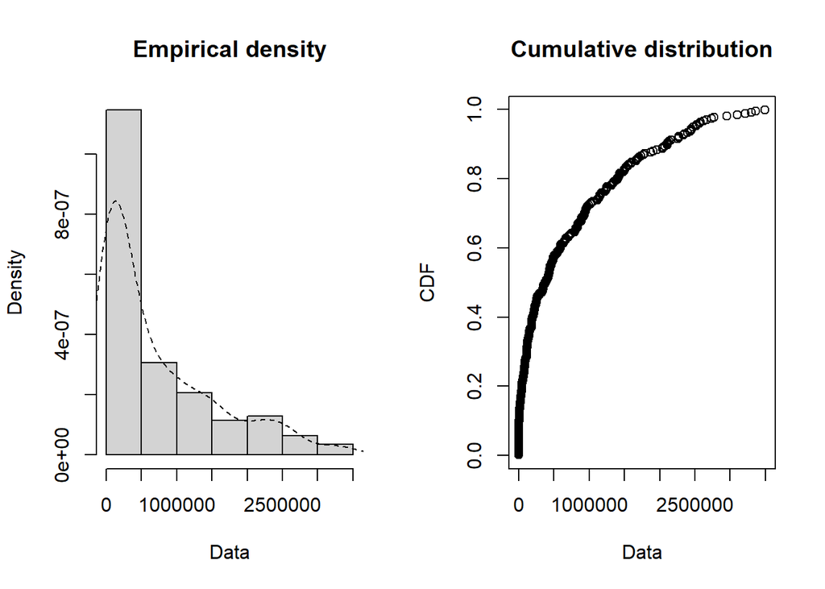

```r
plotdist(II_Data_30C$CFUs, histo=TRUE,demp=TRUE)
```

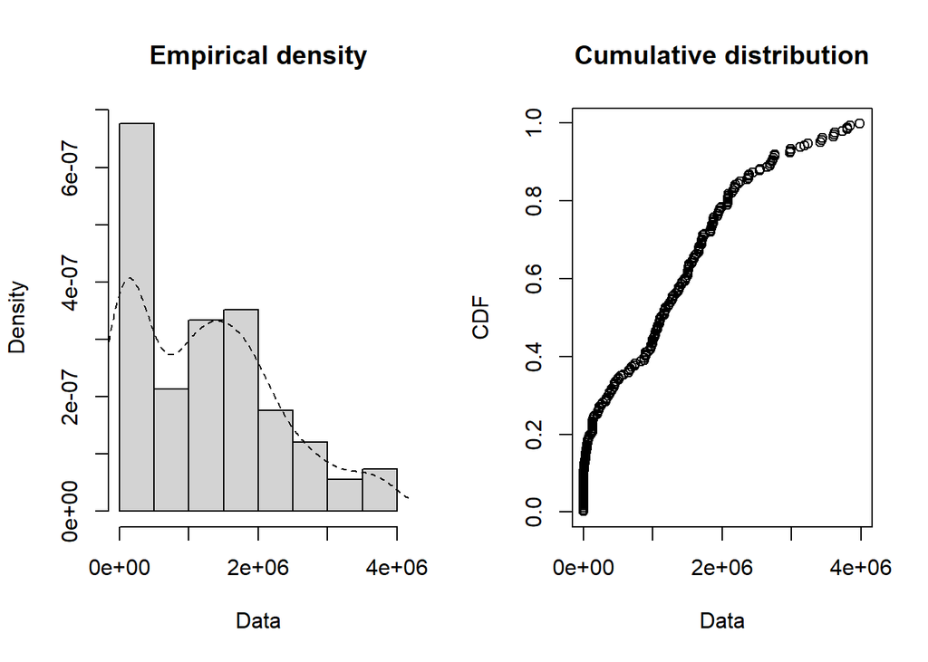

```r
plotdist(II_Data_32C$CFUs, histo=TRUE,demp=TRUE)
```

CFU data varies with Temp and Age, but not infectious dose. There also seem to be a large number of zero count values.

```r
#what percent of the data is made up of zeros?
100*sum(II_Data$CFUs ==0)/nrow(II_Data) #3.16%
```

```
## [1] 3.16092
```

3.16% of the data is made of zero-CFU counts.

What happens if we do a log(x+1) transformation to the CFU data?

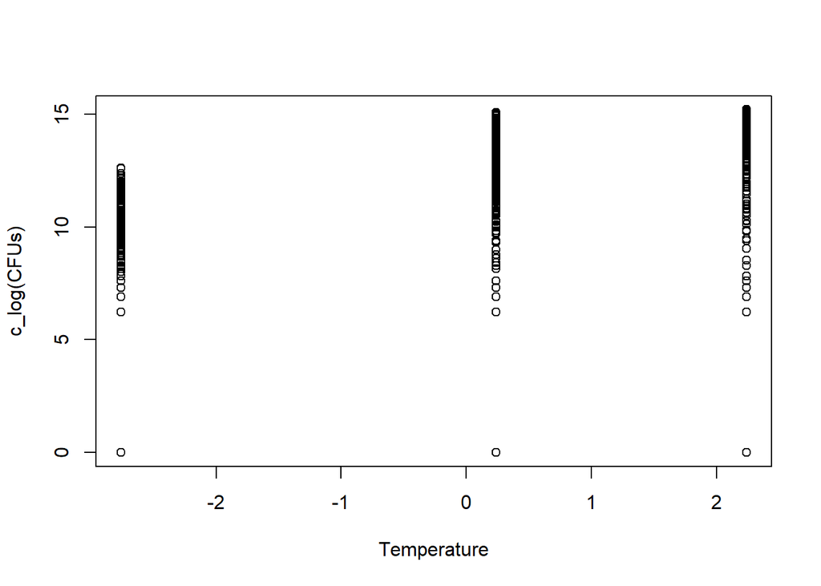

```r
#corrected log equation:
c_log <- function(x) log(x + 1) #add 1.0 so values can be log transformed

#take log to visualize:
plot(c_log(CFUs) ~ Temperature, data = II_Data)
```

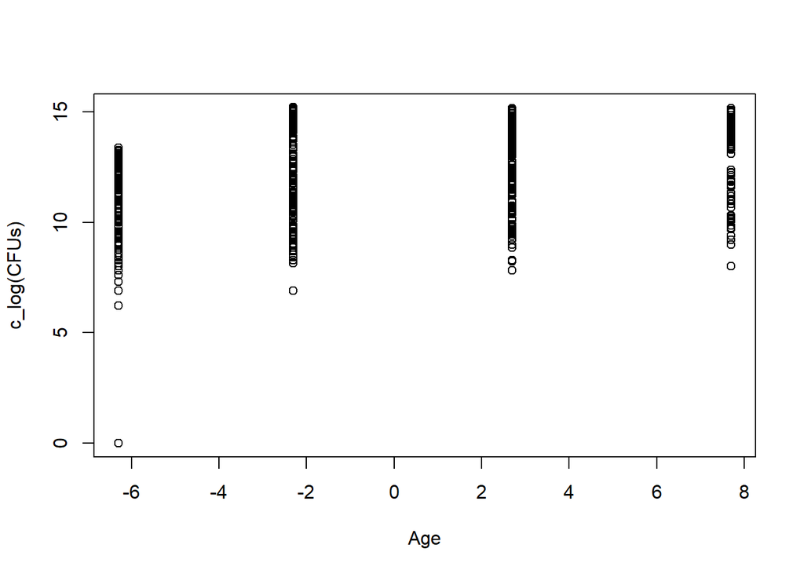

```r
plot(c_log(CFUs) ~ Age, data = II_Data)
```

```r
II_Data$logCFUs <- c_log(II_Data$CFUs)
```

Now, plot the empirical distribution and densities for the CFU and log(x+1) transformed CFU data. Follow up with descriptive statistics of the data -

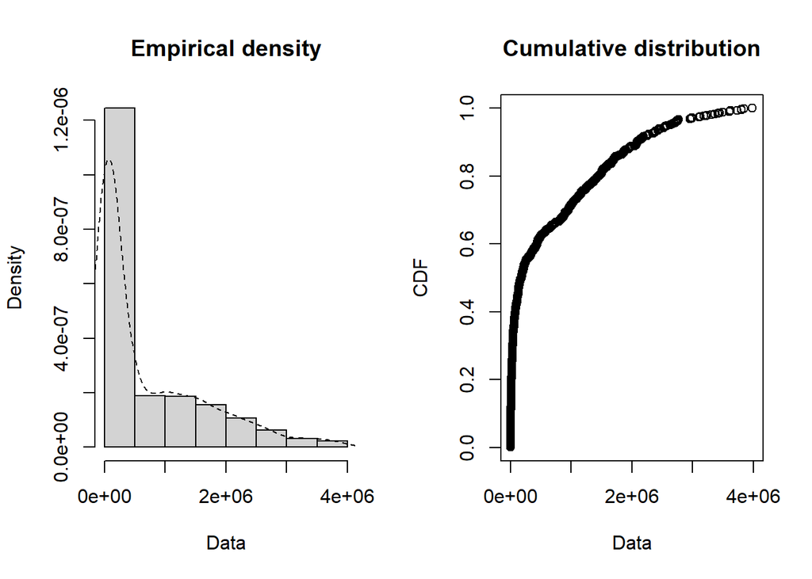

```r
#plot the empirical distribution and density (CDF)
plotdist(II_Data$CFUs, histo=TRUE,demp=TRUE)
```

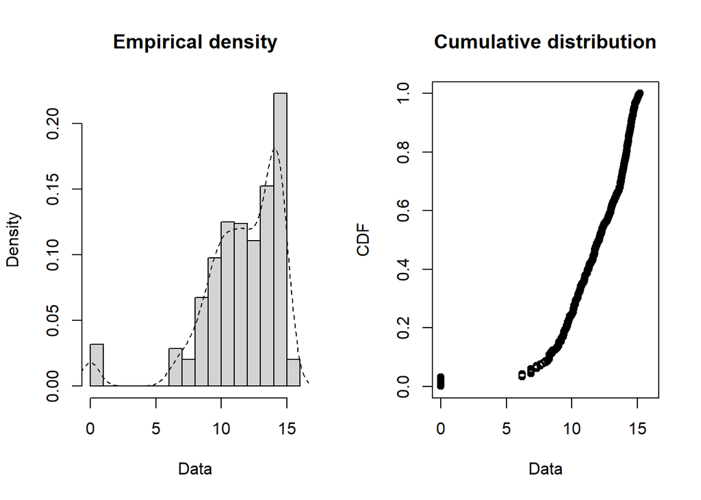

```r
plotdist(c_log(II_Data$CFUs),histo=TRUE,demp=TRUE)
```

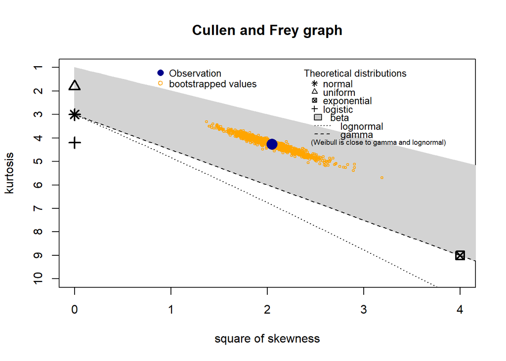

```
## summary statistics
## ------
## min:  0   max:  3984000
## median:  180500
## mean:  681923.5
## estimated sd:  906744.2
## estimated skewness:  1.431304
## estimated kurtosis:  4.26786
```

```r
#descriptive statistics of the data and graph
descdist(II_Data$CFUs, boot = 1000)
```

We are estimating skewness and kurtosis, using bootstrap samples. This is constructed by random sampling with replacement from original data set. There is high variance regardless of bootstrapping.

How does the variance compare to the mean of the CFU data?

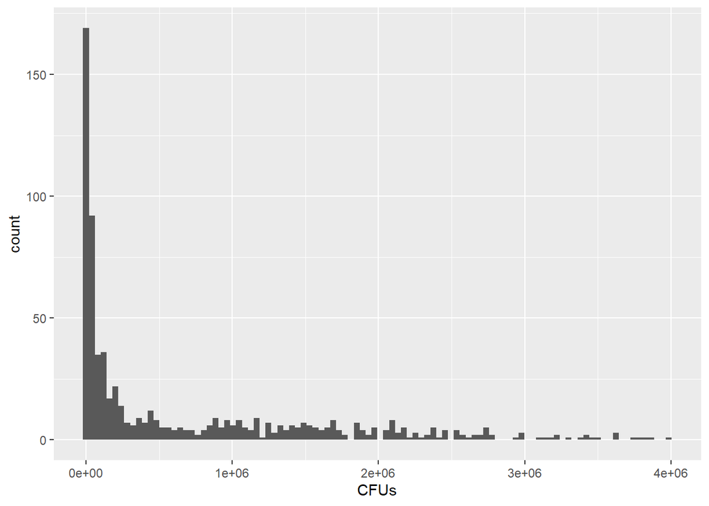

```r
#check mean and variance of CFU data
ggplot(II_Data, aes(x=CFUs)) +
  geom_histogram(bins = 100)
```

```r
r <- c(mean(II_Data$CFUs), var(II_Data$CFUs))
c(mean=r[1],var=r[2],ratio=r[2]/r[1]) #ratio is 1.2e6 (greater than 1.1 and considered large / overdispersed)
```

```
##         mean          var        ratio
## 6.819235e+05 8.221851e+11 1.205685e+06
```

Poisson assumption of equal mean and variance does not hold true. The variance is greater than the mean (ratio = 1.2e6) and is considered over-dispersed.

This suggests a Neg Binom model may be better (mean does not equal variance, which is assumed by Poisson dist).

First, we’ll look at the Poisson dist and Neg Bin dist.

```r
#assess fits:
#check to see if the data follow a poisson distribution
fit_poisson_CFUs <- fitdist((II_Data$CFUs),"pois")
summary(fit_poisson_CFUs)
```

```
## Fitting of the distribution ' pois ' by maximum likelihood
## Parameters :
##        estimate Std. Error
## lambda 681923.5         NA
## Loglikelihood:  -381063613   AIC:  762127229   BIC:  762127233
```

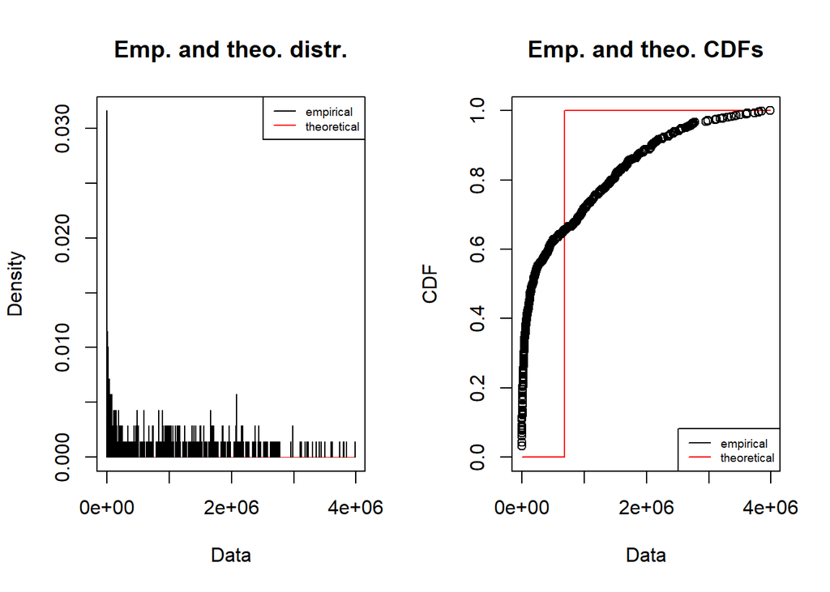

```r
plot(fit_poisson_CFUs)
```

```r
#check to see if the data follow a negative binomial distribution
fit_negbinom_CFUs <- fitdist((II_Data$CFUs), "nbinom")
summary(fit_negbinom_CFUs)
```

```
## Fitting of the distribution ' nbinom ' by maximum likelihood
## Parameters :
##          estimate Std. Error
## size 3.420331e-01         NA
## mu   6.822661e+05         NA
## Loglikelihood:  -9629.12   AIC:  19262.24   BIC:  19271.33
## Correlation matrix:
## [1] NA
```

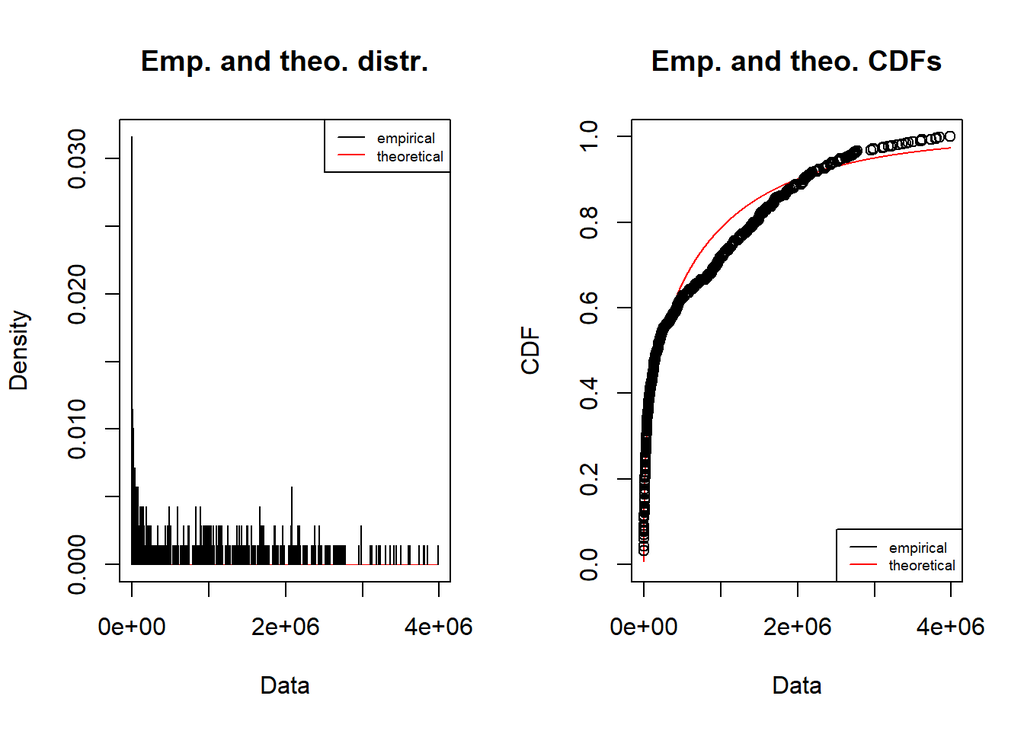

```r
plot(fit_negbinom_CFUs)
```

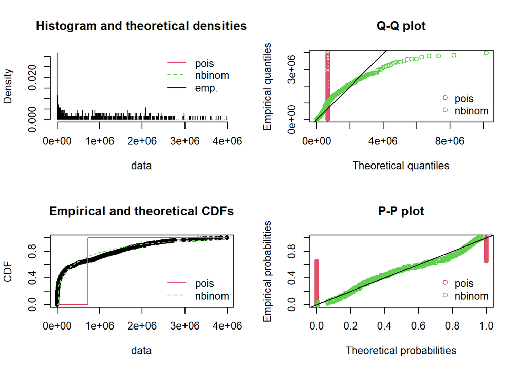

```r
#compare the two fits:

par(mfrow = c(2, 2))
#graphics.off()
plot.legend <- c("pois", "nbinom")
denscomp(list(fit_poisson_CFUs,fit_negbinom_CFUs),legendtext = plot.legend)
qqcomp(list(fit_poisson_CFUs,fit_negbinom_CFUs),legendtext = plot.legend)
cdfcomp(list(fit_poisson_CFUs,fit_negbinom_CFUs),legendtext = plot.legend)
ppcomp(list(fit_poisson_CFUs,fit_negbinom_CFUs),legendtext = plot.legend)
```

```r
#check goodness of fit statistics - chi square for discrete data
gofstat(list(fit_negbinom_CFUs, fit_poisson_CFUs),
        fitnames = c("nbinom", "pois"))
```

```
## Chi-squared statistic:  109.6618 Inf
## Degree of freedom of the Chi-squared distribution:  20 21
## Chi-squared p-value:  2.263674e-14 0
##    the p-value may be wrong with some theoretical counts < 5
## Chi-squared table:
##            obscounts theo nbinom theo pois
## <= 500            30    45.79180         0
## <= 3000           30    38.66537         0
## <= 6500           29    25.51343         0
## <= 11000          29    21.60291         0
## <= 16000          33    17.89404         0
## <= 25000          32    24.44854         0
## <= 35000          30    20.96379         0
## <= 47000          29    20.34635         0
## <= 71000          29    31.86313         0
## <= 106000         29    35.05328         0
## <= 135000         29    23.21798         0
## <= 188000         29    34.37366         0
## <= 272000         29    41.78116         0
## <= 430000         29    56.26156         0
## <= 592000         31    41.36140         0
## <= 888000         31    53.08861       696
## <= 1052000        29    21.73324         0
## <= 1276000        29    23.91389         0
## <= 1504000        30    19.32710         0
## <= 1720000        30    14.84938         0
## <= 2080000        30    19.27904         0
## <= 2472000        29    15.43783         0
## > 2472000         41    49.23252         0
##
## Goodness-of-fit criteria
##                                  nbinom      pois
## Akaike's Information Criterion 19262.24 762127229
## Bayesian Information Criterion 19271.33 762127233
```

```r
#negative binomial model is a much better fit than poisson

#for the log CFUs dist:
fit_norm_logCFUs <- fitdist((II_Data$logCFUs),"norm")
summary(fit_norm_logCFUs)
```

```
## Fitting of the distribution ' norm ' by maximum likelihood
## Parameters :
##       estimate Std. Error
## mean 11.555800 0.11575962
## sd    3.053948 0.08185437
## Loglikelihood:  -1764.62   AIC:  3533.24   BIC:  3542.331
## Correlation matrix:
##               mean            sd
## mean  1.000000e+00 -2.693079e-10
## sd   -2.693079e-10  1.000000e+00
```

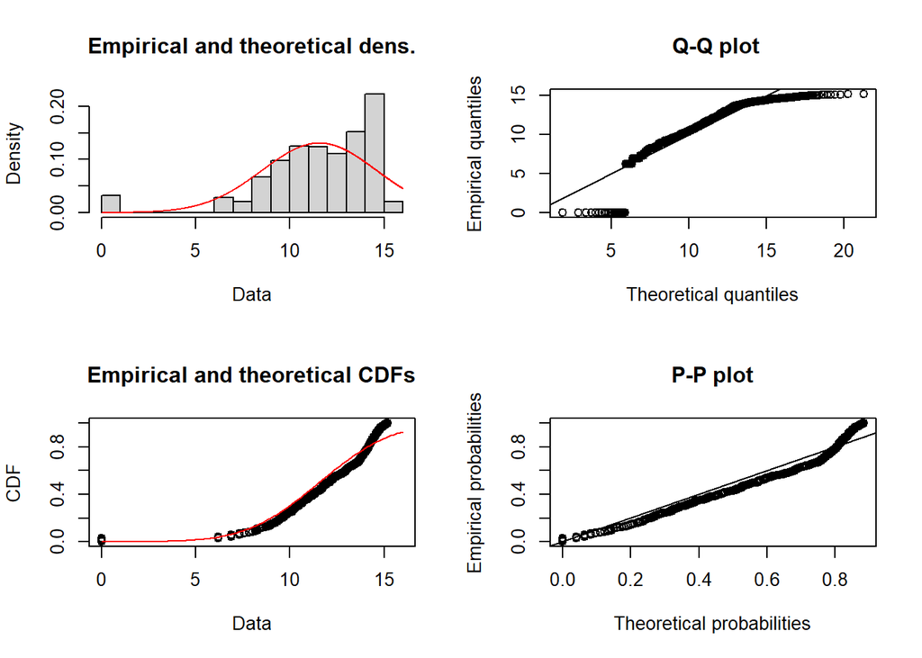

```r
plot(fit_norm_logCFUs)
```

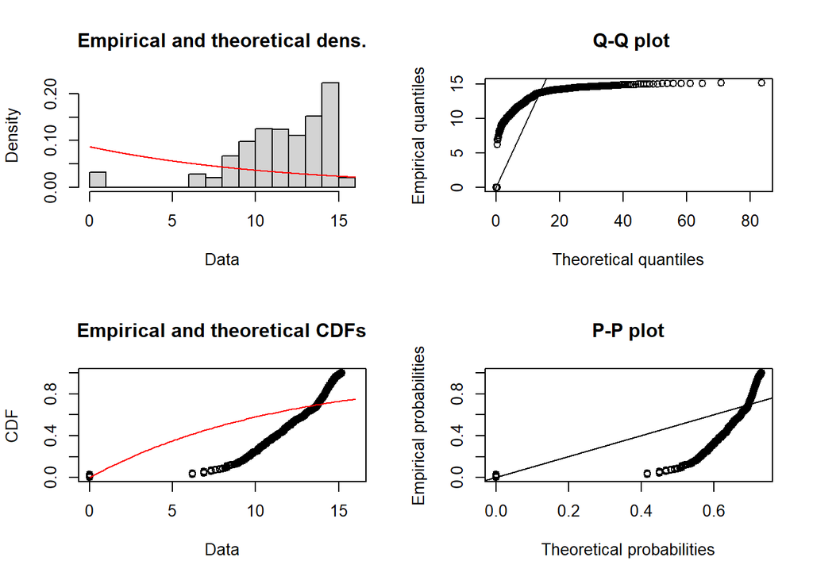

```r
#fit_poisson_logCFUs <- fitdist((II_Data$logCFUs),"pois")

fit_exp_logCFUs <- fitdist((II_Data$logCFUs),"exp")
plot(fit_exp_logCFUs) #not good
```

```r
##############
##model fitting:
#fit Poisson, quasiPoisson, and negative binomial distributions with log link (modeling the mean not the actual data using log link)
glmPoisson <- glm(CFUs ~ Temperature*Age, data=II_Data, family = poisson(link = "log"))
glmQuasiPoisson <- glm(CFUs ~ Temperature*Age, data=II_Data, family = quasipoisson(link = "log"))
glmNegBinomial <- glm.nb(CFUs ~ Temperature*Age, data=II_Data,link="log")
glmNegBinomial_additive <- glm.nb(CFUs ~ Temperature+Age, data=II_Data,link="log") #leaves out interaction term
```

```r
#check models:
summary(glmPoisson)
```

```
##
## Call:
## glm(formula = CFUs ~ Temperature * Age, family = poisson(link = "log"),
##     data = II_Data)
##
## Coefficients:
##                   Estimate Std. Error z value Pr(>|z|)
## (Intercept)      1.280e+01  8.931e-05  143278   <2e-16 ***
## Temperature      5.581e-01  4.554e-05   12255   <2e-16 ***
## Age              1.478e-01  1.475e-05   10016   <2e-16 ***
## Temperature:Age -1.739e-02  7.866e-06   -2211   <2e-16 ***
## ---
## Signif. codes:  0 '***' 0.001 '**' 0.01 '*' 0.05 '.' 0.1 ' ' 1
##
## (Dispersion parameter for poisson family taken to be 1)
##
##     Null deviance: 762117945  on 695  degrees of freedom
## Residual deviance: 342540627  on 692  degrees of freedom
## AIC: 342549916
##
## Number of Fisher Scoring iterations: 6
```

```r
#Residual deviance: 342540627  on 692  degrees of freedom
#AIC: 342549916

summary(glmQuasiPoisson)
```

```
##
## Call:
## glm(formula = CFUs ~ Temperature * Age, family = quasipoisson(link = "log"),
##     data = II_Data)
##
## Coefficients:
##                  Estimate Std. Error t value Pr(>|t|)
## (Intercept)     12.795840   0.066245 193.160  < 2e-16 ***
## Temperature      0.558080   0.033778  16.522  < 2e-16 ***
## Age              0.147754   0.010942  13.503  < 2e-16 ***
## Temperature:Age -0.017391   0.005835  -2.981  0.00298 **
## ---
## Signif. codes:  0 '***' 0.001 '**' 0.01 '*' 0.05 '.' 0.1 ' ' 1
##
## (Dispersion parameter for quasipoisson family taken to be 550206.2)
##
##     Null deviance: 762117945  on 695  degrees of freedom
## Residual deviance: 342540627  on 692  degrees of freedom
## AIC: NA
##
## Number of Fisher Scoring iterations: 6
```

```r
#Residual deviance: 342540627  on 692  degrees of freedom
#AIC: NA

summary(glmNegBinomial)
```

```
##
## Call:
## glm.nb(formula = CFUs ~ Temperature * Age, data = II_Data, link = "log",
##     init.theta = 0.5548731255)
##
## Coefficients:
##                  Estimate Std. Error z value Pr(>|z|)
## (Intercept)     12.641790   0.050975 247.998  < 2e-16 ***
## Temperature      0.704572   0.026296  26.794  < 2e-16 ***
## Age              0.169145   0.010113  16.726  < 2e-16 ***
## Temperature:Age  0.027626   0.005358   5.156 2.52e-07 ***
## ---
## Signif. codes:  0 '***' 0.001 '**' 0.01 '*' 0.05 '.' 0.1 ' ' 1
##
## (Dispersion parameter for Negative Binomial(0.5549) family taken to be 1)
##
##     Null deviance: 1488.50  on 695  degrees of freedom
## Residual deviance:  867.08  on 692  degrees of freedom
## AIC: 18787
##
## Number of Fisher Scoring iterations: 1
##
##
##               Theta:  0.5549
##           Std. Err.:  0.0255
##
##  2 x log-likelihood:  -18776.9520
```